# SRNM_Modeling-Course

# **Model Selection**

Of the last two models, the one with the log-Normal error model would seem to have the more Normal residuals. This can be inspected by looking at diagnostic plots, by and using the `shapiro.test()`:

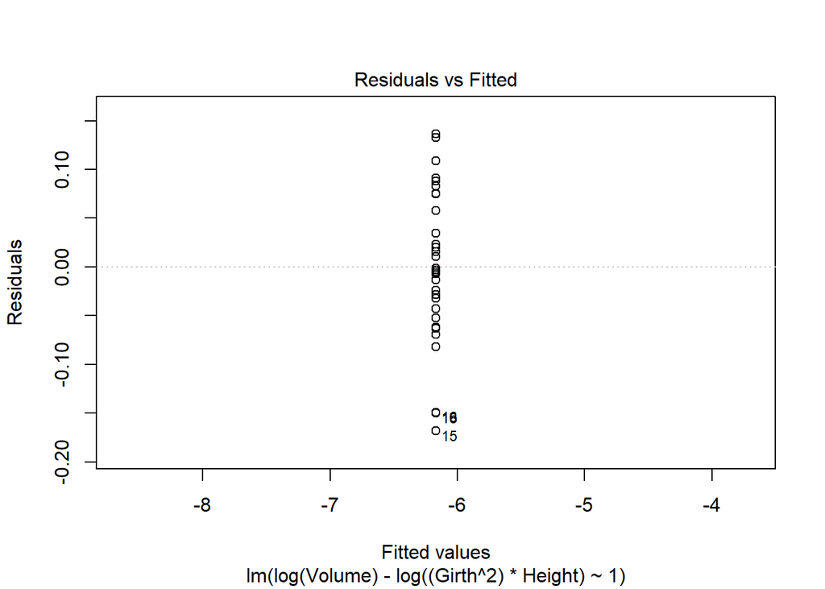

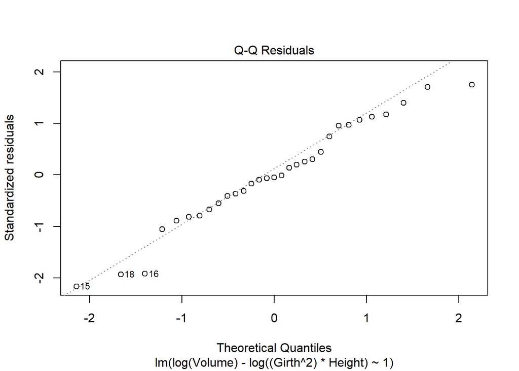

```
## les valeurs estimées ("leverages") sont tous = 0.03225806
##  et il n'y a aucune variable dépendante facteur ; aucun graphe no. 5
```

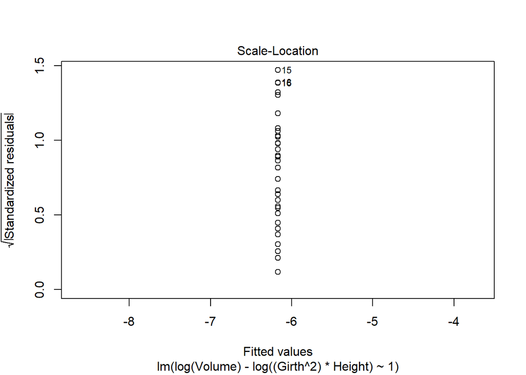

```r
plot(m6)
```

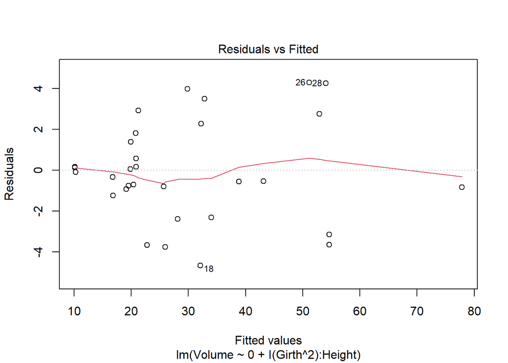

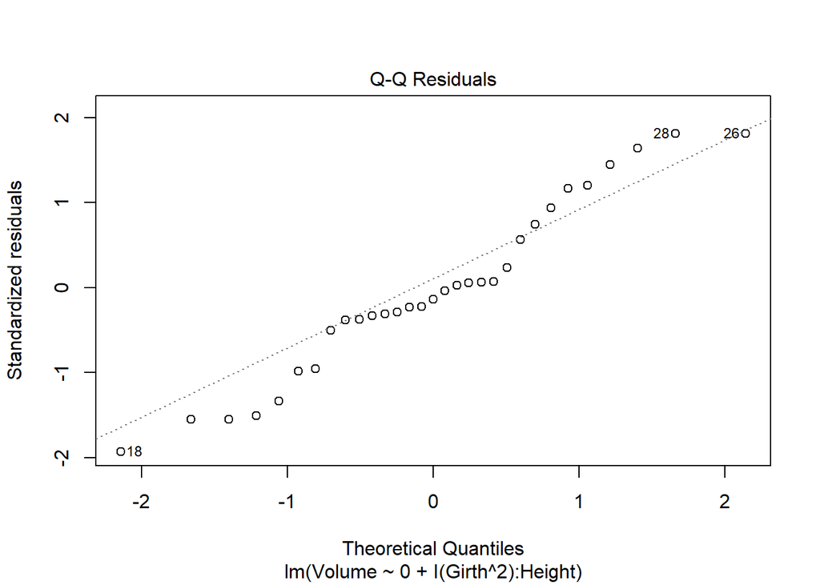

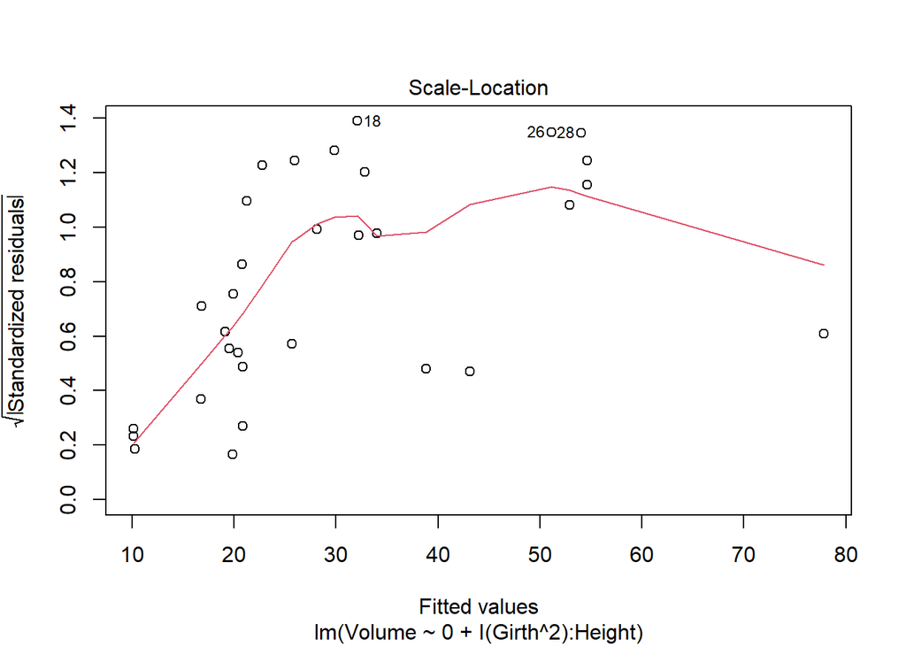

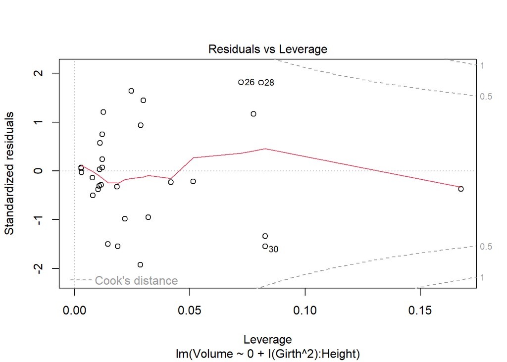

```r
plot(m7)
```

```r
shapiro.test(residuals(m6))
```

```
##
##  Shapiro-Wilk normality test
##
## data:  residuals(m6)
## W = 0.97013, p-value = 0.5225
```

```r
shapiro.test(residuals(m7))
```

```
##
##  Shapiro-Wilk normality test
##
## data:  residuals(m7)
## W = 0.95846, p-value = 0.2655
```

The Akaike Information Criterion (AIC) can help to make decisions regarding which model is the most appropriate. Now calculate the AIC for each of the above models:

```r
summary(m1)
```

```
##
## Call:
## lm(formula = Volume ~ Girth, data = trees)
##
## Residuals:
##    Min     1Q Median     3Q    Max
## -8.065 -3.107  0.152  3.495  9.587
##
## Coefficients:
##             Estimate Std. Error t value Pr(>|t|)
## (Intercept) -36.9435     3.3651  -10.98 7.62e-12 ***
## Girth         5.0659     0.2474   20.48  < 2e-16 ***
## ---
## Signif. codes:  0 '***' 0.001 '**' 0.01 '*' 0.05 '.' 0.1 ' ' 1
##
## Residual standard error: 4.252 on 29 degrees of freedom
## Multiple R-squared:  0.9353, Adjusted R-squared:  0.9331
## F-statistic: 419.4 on 1 and 29 DF,  p-value: < 2.2e-16
```

```r
AIC(m1)
```

```
## [1] 181.6447
```

```r
summary(m2)
```

```
##
## Call:
## lm(formula = Volume ~ Girth + Height, data = trees)
##
## Residuals:
##     Min      1Q  Median      3Q     Max
## -6.4065 -2.6493 -0.2876  2.2003  8.4847
##
## Coefficients:
##             Estimate Std. Error t value Pr(>|t|)
## (Intercept) -57.9877     8.6382  -6.713 2.75e-07 ***
## Girth         4.7082     0.2643  17.816  < 2e-16 ***
## Height        0.3393     0.1302   2.607   0.0145 *
## ---
## Signif. codes:  0 '***' 0.001 '**' 0.01 '*' 0.05 '.' 0.1 ' ' 1
##
## Residual standard error: 3.882 on 28 degrees of freedom
## Multiple R-squared:  0.948,  Adjusted R-squared:  0.9442
## F-statistic:   255 on 2 and 28 DF,  p-value: < 2.2e-16
```

```r
AIC(m2)
```

```
## [1] 176.91
```

```r
summary(m3)
```

```
##
## Call:
## lm(formula = Volume ~ Girth * Height, data = trees)
##
## Residuals:
##     Min      1Q  Median      3Q     Max
## -6.5821 -1.0673  0.3026  1.5641  4.6649
##
## Coefficients:
##              Estimate Std. Error t value Pr(>|t|)
## (Intercept)  69.39632   23.83575   2.911  0.00713 **
## Girth        -5.85585    1.92134  -3.048  0.00511 **
## Height       -1.29708    0.30984  -4.186  0.00027 ***
## Girth:Height  0.13465    0.02438   5.524 7.48e-06 ***
## ---
## Signif. codes:  0 '***' 0.001 '**' 0.01 '*' 0.05 '.' 0.1 ' ' 1
##
## Residual standard error: 2.709 on 27 degrees of freedom
## Multiple R-squared:  0.9756, Adjusted R-squared:  0.9728
## F-statistic: 359.3 on 3 and 27 DF,  p-value: < 2.2e-16
```

```r
AIC(m3)
```

```
## [1] 155.4692
```

```r
summary(m4)
```

```
##
## Call:
## lm(formula = log(Volume) ~ log(Girth) + log(Height), data = trees)
##
## Residuals:
##       Min        1Q    Median        3Q       Max
## -0.168561 -0.048488  0.002431  0.063637  0.129223
##
## Coefficients:
##             Estimate Std. Error t value Pr(>|t|)
## (Intercept) -6.63162    0.79979  -8.292 5.06e-09 ***
## log(Girth)   1.98265    0.07501  26.432  < 2e-16 ***
## log(Height)  1.11712    0.20444   5.464 7.81e-06 ***
## ---
## Signif. codes:  0 '***' 0.001 '**' 0.01 '*' 0.05 '.' 0.1 ' ' 1
##
## Residual standard error: 0.08139 on 28 degrees of freedom
## Multiple R-squared:  0.9777, Adjusted R-squared:  0.9761
## F-statistic: 613.2 on 2 and 28 DF,  p-value: < 2.2e-16
```

```r
AIC(m4)
```

```
## [1] -62.71125
```

```r
summary(m5)
```

```
##
## Call:
## lm(formula = log(Volume) ~ log(Girth) * log(Height), data = trees)
##
## Residuals:
##       Min        1Q    Median        3Q       Max
## -0.165941 -0.048613  0.006384  0.062204  0.132295
##
## Coefficients:
##                        Estimate Std. Error t value Pr(>|t|)
## (Intercept)             -3.6869     7.6996  -0.479    0.636
## log(Girth)               0.7942     3.0910   0.257    0.799
## log(Height)              0.4377     1.7788   0.246    0.808
## log(Girth):log(Height)   0.2740     0.7124   0.385    0.704
##
## Residual standard error: 0.08265 on 27 degrees of freedom
## Multiple R-squared:  0.9778, Adjusted R-squared:  0.9753
## F-statistic: 396.4 on 3 and 27 DF,  p-value: < 2.2e-16
```

```r
AIC(m5)
```

```
## [1] -60.88061
```

```r
summary(m6)
```

```
##
## Call:
## lm(formula = log(Volume) - log((Girth^2) * Height) ~ 1, data = trees)
##
## Residuals:
##       Min        1Q    Median        3Q       Max
## -0.168446 -0.047355 -0.003518  0.066308  0.136467
##
## Coefficients:
##             Estimate Std. Error t value Pr(>|t|)
## (Intercept) -6.16917    0.01421  -434.3   <2e-16 ***
## ---
## Signif. codes:  0 '***' 0.001 '**' 0.01 '*' 0.05 '.' 0.1 ' ' 1
##
## Residual standard error: 0.0791 on 30 degrees of freedom
```

```r
AIC(m6)
```

```
## [1] -66.34198
```

```r
summary(m7)
```

```
##
## Call:
## lm(formula = Volume ~ 0 + I(Girth^2):Height, data = trees)
##
## Residuals:
##     Min      1Q  Median      3Q     Max
## -4.6696 -1.0832 -0.3341  1.6045  4.2944
##
## Coefficients:
##                    Estimate Std. Error t value Pr(>|t|)
## I(Girth^2):Height 2.108e-03  2.722e-05   77.44   <2e-16 ***
## ---
## Signif. codes:  0 '***' 0.001 '**' 0.01 '*' 0.05 '.' 0.1 ' ' 1
##
## Residual standard error: 2.455 on 30 degrees of freedom
## Multiple R-squared:  0.995,  Adjusted R-squared:  0.9949
## F-statistic:  5996 on 1 and 30 DF,  p-value: < 2.2e-16
```

```r
AIC(m7)
```

```
## [1] 146.6447
```

Whilst the AIC can help differentiate between similar models, it cannot help deciding between models that have different responses. Which model would you select as the most appropriate?

# **Stepwise Regression**

The in-built dataset `swiss` contains data pertaining to fertility, along with a variety of socioeconomic indicators. We want to select a sensible model using stepwise regression. First regress `Fertility` agains all available indicators:

```r
m8 = lm(Fertility~.,data=swiss)
summary(m8)
```

```
##
## Call:
## lm(formula = Fertility ~ ., data = swiss)
##
## Residuals:
##      Min       1Q   Median       3Q      Max
## -15.2743  -5.2617   0.5032   4.1198  15.3213
##
## Coefficients:
##                  Estimate Std. Error t value Pr(>|t|)
## (Intercept)      66.91518   10.70604   6.250 1.91e-07 ***
## Agriculture      -0.17211    0.07030  -2.448  0.01873 *
## Examination      -0.25801    0.25388  -1.016  0.31546
## Education        -0.87094    0.18303  -4.758 2.43e-05 ***
## Catholic          0.10412    0.03526   2.953  0.00519 **
## Infant.Mortality  1.07705    0.38172   2.822  0.00734 **
## ---
## Signif. codes:  0 '***' 0.001 '**' 0.01 '*' 0.05 '.' 0.1 ' ' 1
##
## Residual standard error: 7.165 on 41 degrees of freedom
## Multiple R-squared:  0.7067, Adjusted R-squared:  0.671
## F-statistic: 19.76 on 5 and 41 DF,  p-value: 5.594e-10
```

Are all terms significant?

Now use stepwise regression, performing backward elimination in order to automatically remove inappropriate terms:

```r
library(MASS)
summary(stepAIC(m8))
```

```
## Start:  AIC=190.69
## Fertility ~ Agriculture + Examination + Education + Catholic +
##     Infant.Mortality
##
##                    Df Sum of Sq    RSS    AIC
## - Examination       1     53.03 2158.1 189.86
## <none>                          2105.0 190.69
## - Agriculture       1    307.72 2412.8 195.10
## - Infant.Mortality  1    408.75 2513.8 197.03
## - Catholic          1    447.71 2552.8 197.75
## - Education         1   1162.56 3267.6 209.36
##
## Step:  AIC=189.86
## Fertility ~ Agriculture + Education + Catholic + Infant.Mortality
##
##                    Df Sum of Sq    RSS    AIC
## <none>                          2158.1 189.86
## - Agriculture       1    264.18 2422.2 193.29
## - Infant.Mortality  1    409.81 2567.9 196.03
## - Catholic          1    956.57 3114.6 205.10
## - Education         1   2249.97 4408.0 221.43
```

```
##
## Call:
## lm(formula = Fertility ~ Agriculture + Education + Catholic +
##     Infant.Mortality, data = swiss)
##
## Residuals:
##      Min       1Q   Median       3Q      Max
## -14.6765  -6.0522   0.7514   3.1664  16.1422
##
## Coefficients:
##                  Estimate Std. Error t value Pr(>|t|)
## (Intercept)      62.10131    9.60489   6.466 8.49e-08 ***
## Agriculture      -0.15462    0.06819  -2.267  0.02857 *
## Education        -0.98026    0.14814  -6.617 5.14e-08 ***
## Catholic          0.12467    0.02889   4.315 9.50e-05 ***
## Infant.Mortality  1.07844    0.38187   2.824  0.00722 **
## ---
## Signif. codes:  0 '***' 0.001 '**' 0.01 '*' 0.05 '.' 0.1 ' ' 1
##
## Residual standard error: 7.168 on 42 degrees of freedom
## Multiple R-squared:  0.6993, Adjusted R-squared:  0.6707
## F-statistic: 24.42 on 4 and 42 DF,  p-value: 1.717e-10
```

Are all terms significant? Is this model suitable? What are the pro’s and con’s of this approach?

# **Non-Linear Models**

The in-built dataset `trees` contains data pertaining to the `Volume`, `Girth` and `Height` of 31 felled black cherry trees.

In the Simple Regression session, we constructed a simple linear model for `Volume` using `Girth` as the independent variable. Using Multiple Regression we trialled various models, including some that had multiple predictor variables and/or involved log-log transformations to explore power relationships.

However, due to limitations of the method, we were not able to explore other options such as a parameterised power relationship with an additive error model. We will now attempt to fit this model:

$y = \beta_0x_1^{\beta_1}x_2^{\beta_2}+\varepsilon$

Parameters for non-linear models may be estimated using the `nls` package in R.

```r
volume = trees$Volume
height = trees$Height
girth = trees$Girth
m9 = nls(volume~beta0*girth^beta1*height^beta2,start=list(beta0=1,beta1=2,beta2=1))
summary(m9)
```

```
##
## Formula: volume ~ beta0 * girth^beta1 * height^beta2
##
## Parameters:
##       Estimate Std. Error t value Pr(>|t|)
## beta0 0.001449   0.001367   1.060 0.298264
## beta1 1.996921   0.082077  24.330  < 2e-16 ***
## beta2 1.087647   0.242159   4.491 0.000111 ***
## ---
## Signif. codes:  0 '***' 0.001 '**' 0.01 '*' 0.05 '.' 0.1 ' ' 1
##
## Residual standard error: 2.533 on 28 degrees of freedom
##
## Number of iterations to convergence: 5
## Achieved convergence tolerance: 7.579e-07
```

Note that the parameters `beta0`, `beta1` and `beta2` weren’t defined prior to the function call - `nls` knew what to do with them. Also note that we had to provide starting points for the parameters. What happens if you change them?

Are all terms significant? Is this model appropriate? What else could be tried to achieve a better model?

# **Practical Exercises**

## Puromycin

The in-built R dataset `Puromycin` contains data regarding the reaction velocity versus substrate concentration in an enzymatic reaction involving untreated cells or cells treated with Puromycin.

- Plot `conc` (concentration) against `rate`. What is the nature of the relationship between `conc` and `rate`?
- Find a transformation that linearises the data and stabilises the variance, making it possible to use linear regression. Create the corresponding linear regression model. Are all terms significant?
- Add the `state` term to the model. What type of variable is this? Is the inclusion of this term appropriate?
- Now add a term representing the interaction between `rate` and `state`. Are all terms significant? What can you conclude?
- Given this information, create the regression model you believe to be the most appropriate for modelling `conc`. Regenerate the plot of `conc` against `rate`. Draw curves corresponding to the fitted values of the final model onto this plot (note that two separate curves should be drawn, corresponding to the two levels of `state`).

## Attitude

The in-built R dataset `attitude` contains data from a survey of clerical employees.

- Create a linear model regressing `rating` on `complaints`, and store the model in a variable.
- Use the step function to perform forward selection stepwise regression, in order to automatically add appropriate terms, using a command similar to: `new_model = step(original_model,.~.+privileges+learning+raises+critical+advance)`
- Which term(s) were added? What is Akaike’s Information Criterion (AIC) corresponding to the final model? Are all terms in the resulting model significant? Check diagnostic plots. Do you think this is a suitable model?

# Section 8: **GLM, Logistic regression**

We will analyse the data collected by Jones (Unpublished BSc dissertation, University of Southampton, 1975). The aim of the study was to define if the probability of having Bronchitis is influenced by smoking and/or pollution.

The data are stored under CourseData/Bronchitis.csv and contains information on 212 participants.

### Section 8.1: **importation and descriptive analysis**

Lets starts by

- importing the data set *Bronchitis* with the function `read.csv()`
- displaying *bron* (a dichotomous variable which equals 1 for participants having bronchitis and 0 otherwise) as a function of *cigs*, the number of cigarettes smoked daily.

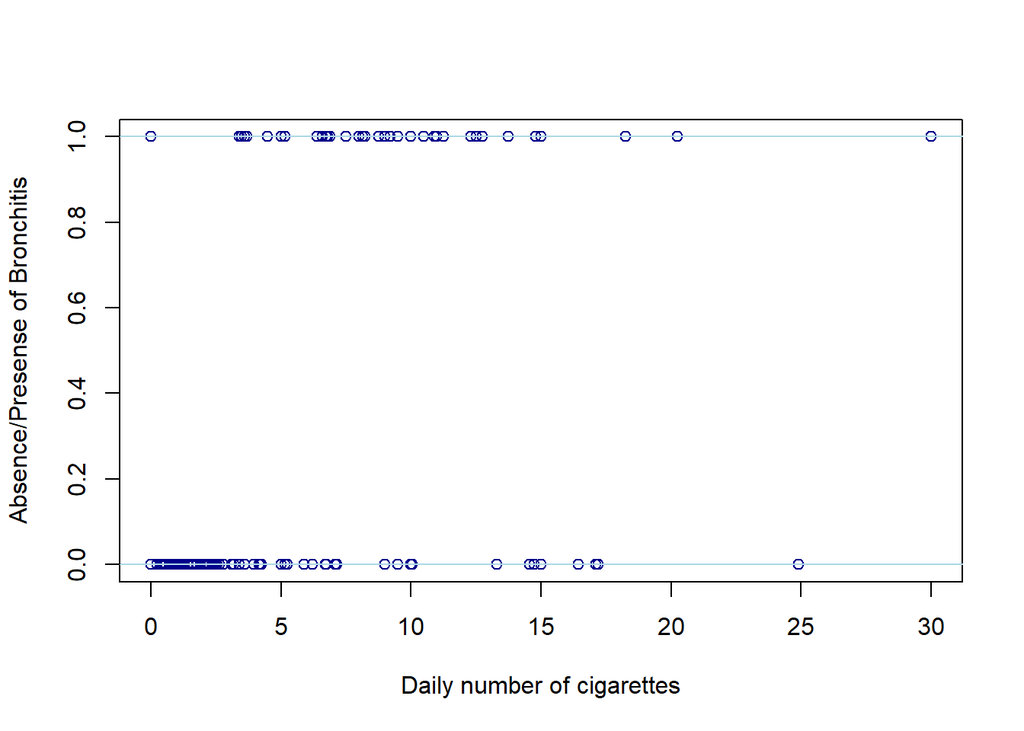

```r
Bronchitis = read.csv("CourseData/Bronchitis.csv",header=TRUE)
plot(Bronchitis$cigs,Bronchitis$bron,col="blue4",
        ylab = "Absence/Presense of Bronchitis", xlab = "Daily number of cigarettes")
abline(h=c(0,1),col="light blue")
```

# Model fit

Lets

- fit a logistic model by means the function `glm()` and by means of the function `gamlss()` of the library `gamlss`.
- display and analyse the results of the `glm` function : Use the function `summary()` to display the results of an R object of class `glm`.

```r
#install.packages("gamlss", type = "binary")
```

```r
fit.glm = glm(bron~cigs,data=Bronchitis,family=binomial)
library(gamlss)
fit.gamlss = gamlss(bron~cigs,data=Bronchitis,family=BI)
```

```
## GAMLSS-RS iteration 1: Global Deviance = 181.7072
## GAMLSS-RS iteration 2: Global Deviance = 181.7072
```

```r
summary(fit.glm)
```

```
##
## Call:
## glm(formula = bron ~ cigs, family = binomial, data = Bronchitis)
##
## Coefficients:
##             Estimate Std. Error z value Pr(>|z|)
## (Intercept)  -2.2840     0.2731  -8.365  < 2e-16 ***
## cigs          0.2094     0.0376   5.567 2.59e-08 ***
## ---
## Signif. codes:  0 '***' 0.001 '**' 0.01 '*' 0.05 '.' 0.1 ' ' 1
##
## (Dispersion parameter for binomial family taken to be 1)
##
##     Null deviance: 221.78  on 211  degrees of freedom
## Residual deviance: 181.71  on 210  degrees of freedom
## AIC: 185.71
##
## Number of Fisher Scoring iterations: 4
```

Let’s now define the estimated probability of having bronchitis for any number of daily smoked cigarette and display the corresponding logistic curve on a plot:

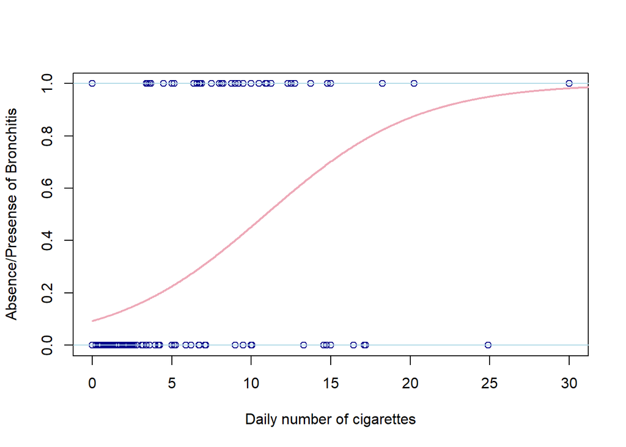

```r
plot(Bronchitis$cigs,Bronchitis$bron,col="blue4",
        ylab = "Absence/Presense of Bronchitis", xlab = "Daily number of cigarettes")
abline(h=c(0,1),col="light blue")

axe.x = seq(0,40,length=1000)
f.x = exp(fit.glm$coef[1]+axe.x*fit.glm$coef[2])/(1+exp(fit.glm$coef[1]+axe.x*fit.glm$coef[2]))
lines(axe.x,f.x,col="pink2",lwd=2)
```

## Model selection

As for linear models, model selection may be done by means of the function `anova()` used on the glm object of interest.

```r
anova(fit.glm,test="LRT")
```

```
## Analysis of Deviance Table
##
## Model: binomial, link: logit
##
## Response: bron
##
## Terms added sequentially (first to last)
##
##
##      Df Deviance Resid. Df Resid. Dev Pr(>Chi)
## NULL                   211     221.78
## cigs  1    40.07       210     181.71 2.45e-10 ***
## ---
## Signif. codes:  0 '***' 0.001 '**' 0.01 '*' 0.05 '.' 0.1 ' ' 1
```

## Model check

Lets assess is the model fit seems satisfactory by means

- of the analysis of deviance residuals (function `plot()` on an object of class `glm`,
- of the analysis of randomised normalised quantile residuals (function `plot()` on an object of class `gamlss`,

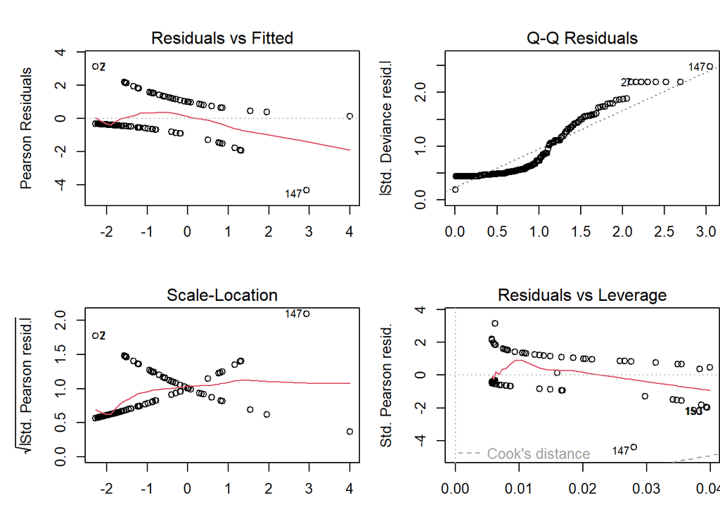

```r
# deviance
par(mfrow=c(2,2),mar=c(3,5,3,0))
plot(fit.glm)
```

```
## GAMLSS-RS iteration 1: Global Deviance = 181.7072
## GAMLSS-RS iteration 2: Global Deviance = 181.7072
```

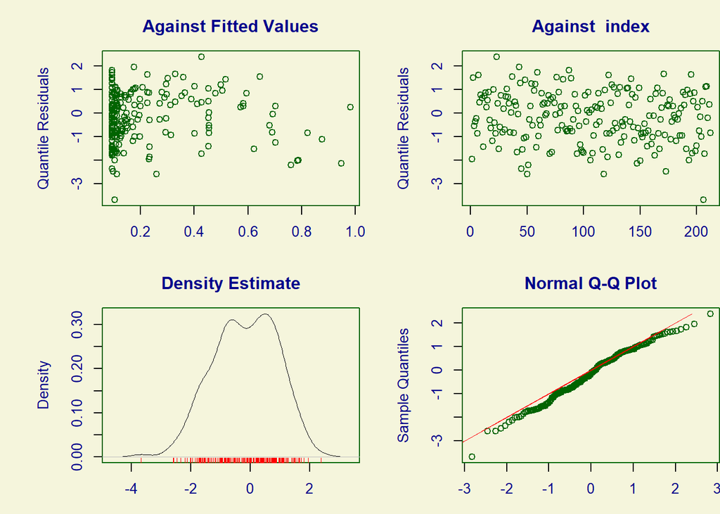

```
##   Summary of the Randomised Quantile Residuals
##                            mean   =  -0.1753139
##                        variance   =  1.143315
##                coef. of skewness  =  -0.2409213
##                coef. of kurtosis  =  2.600015
## Filliben correlation coefficient  =  0.994028
```

```r
# randomised normalised quantile residuals
plot(gamlss(bron~cigs,data=Bronchitis,family=BI))
```

# **Poisson regression**

The dataset *students.csv* shows the number of high school students diagnosed with an infectious disease for each day from the initial disease outbreak.

# Importation

Lets

- import the dataset by means of the function `read.csv()`
- display the daily number of students diagnosed with the disease (variable `cases`) as a function of the days since the outbreak (variable `day`).

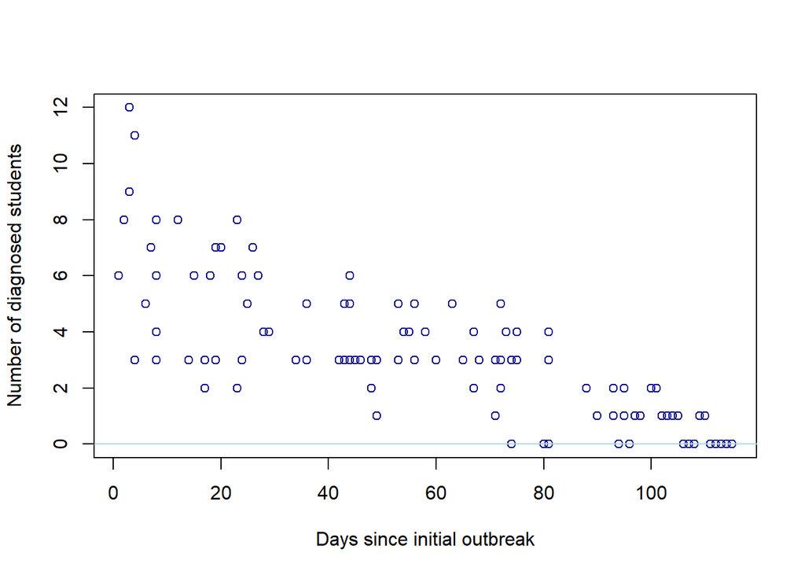

```r
students = read.csv("./CourseData/students.csv",header=TRUE)
plot(students$day,students$cases,col="blue4",
        ylab = "Number of diagnosed students", xlab = "Days since initial outbreak")
abline(h=c(0),col="light blue")
```

# Model fit

Lets

- fit a poisson model by means the function `glm()` and by means of the function `gamlss()` of the library `gamlss`.
- display and analyse the results of the `glm` function : Use the function `summary()` to display the results of an R object of class `glm`.

```r
fit.glm = glm(cases~day,data=students,family=poisson)

library(gamlss)
fit.gamlss = gamlss(cases~day,data=students,,family=PO)
```

```
## GAMLSS-RS iteration 1: Global Deviance = 389.1082
## GAMLSS-RS iteration 2: Global Deviance = 389.1082
```

```r
summary(fit.glm)
```

```
##
## Call:
## glm(formula = cases ~ day, family = poisson, data = students)
##
## Coefficients:
##              Estimate Std. Error z value Pr(>|z|)
## (Intercept)  1.990235   0.083935   23.71   <2e-16 ***
## day         -0.017463   0.001727  -10.11   <2e-16 ***
## ---
## Signif. codes:  0 '***' 0.001 '**' 0.01 '*' 0.05 '.' 0.1 ' ' 1
##
## (Dispersion parameter for poisson family taken to be 1)
##
##     Null deviance: 215.36  on 108  degrees of freedom
## Residual deviance: 101.17  on 107  degrees of freedom
## AIC: 393.11
##
## Number of Fisher Scoring iterations: 5
```

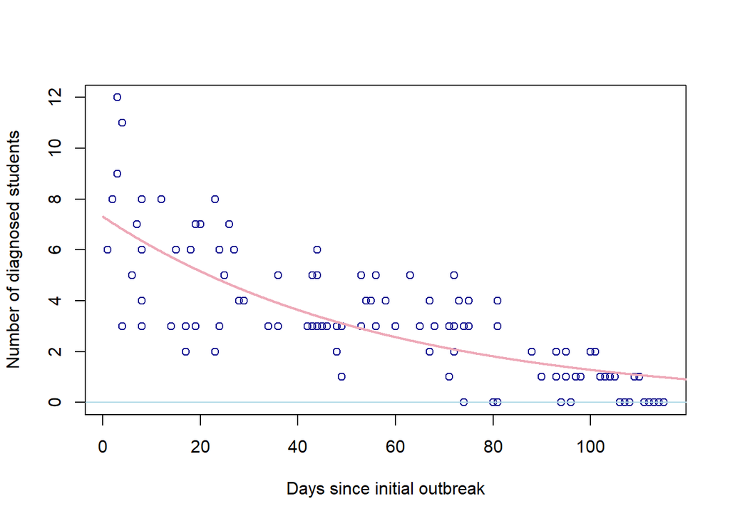

```r
plot(students$day,students$cases,col="blue4",
        ylab = "Number of diagnosed students", xlab = "Days since initial outbreak")
abline(h=c(0),col="light blue")

axe.x = seq(0,120,length=1000)
f.x = exp(fit.glm$coef[1]+axe.x*fit.glm$coef[2])
lines(axe.x,f.x,col="pink2",lwd=2)
```

## Model selection

As for linear models, model selection may be done by means of the function `anova()` used on the glm object of interest.

```r
anova(fit.glm,test="LRT")
```

```
## Analysis of Deviance Table
##
## Model: poisson, link: log
##
## Response: cases
##
## Terms added sequentially (first to last)
##
##
##      Df Deviance Resid. Df Resid. Dev  Pr(>Chi)
## NULL                   108     215.36
## day   1   114.18       107     101.17 < 2.2e-16 ***
## ---
## Signif. codes:  0 '***' 0.001 '**' 0.01 '*' 0.05 '.' 0.1 ' ' 1
```

## Model check

Lets assess is the model fit seems satisfactory by means

- of the analysis of deviance residuals (function `plot()` on an object of class `glm`,
- of the analysis of randomised normalised quantile residuals (function `plot()` on an object of class `gamlss`,

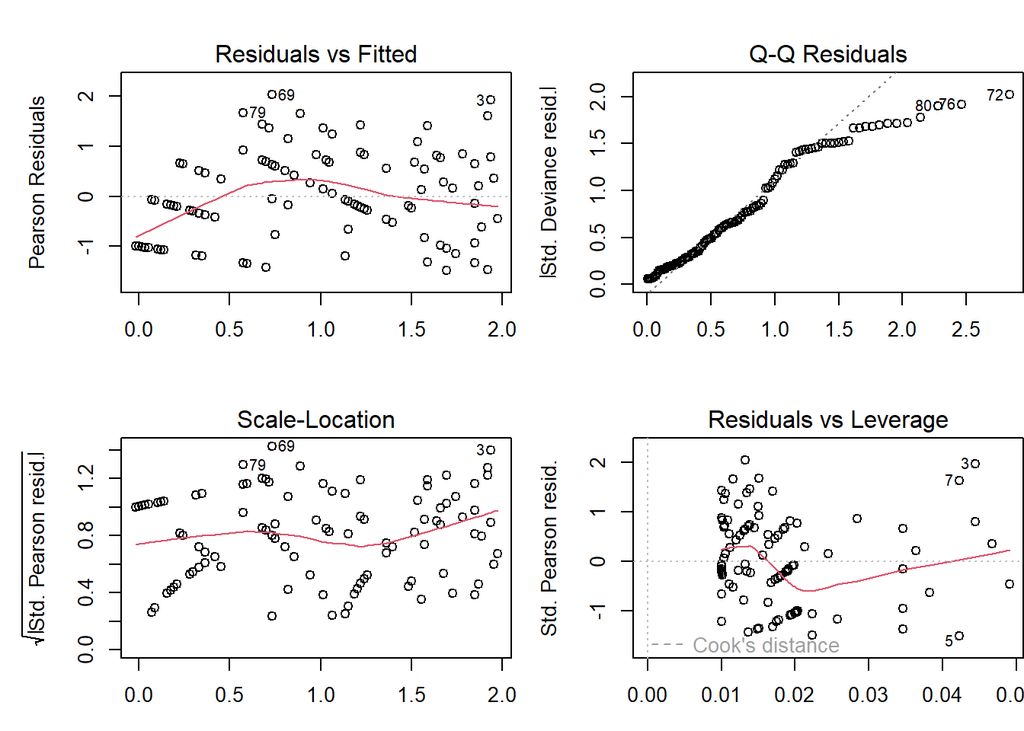

```r
# deviance
par(mfrow=c(2,2),mar=c(3,5,3,0))
plot(fit.glm)
```

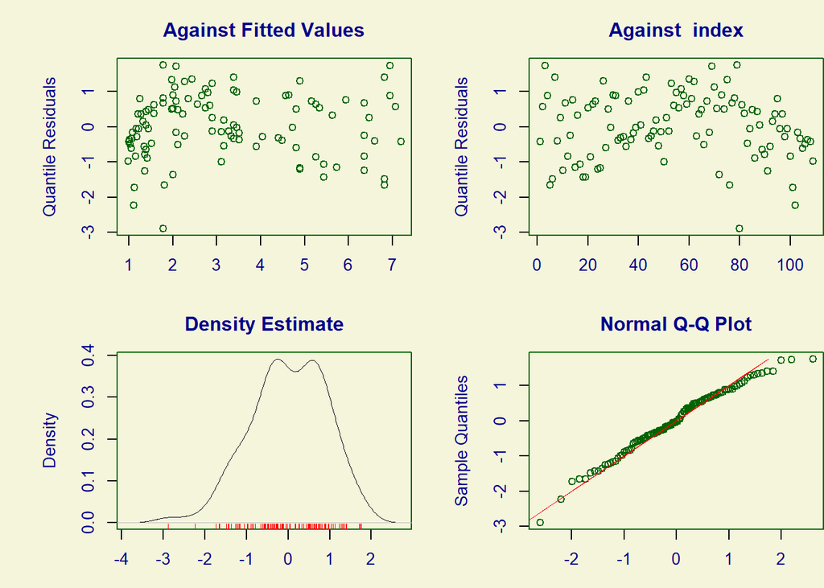

```
##   Summary of the Randomised Quantile Residuals
##                            mean   =  0.006619112
##                        variance   =  0.8230451
##                coef. of skewness  =  -0.4004802
##                coef. of kurtosis  =  2.926797
## Filliben correlation coefficient  =  0.9915057
```

```r
# randomised normalised quantile residuals
plot(fit.gamlss)
```

# **Practicals Exercices**

### (i) *Bronchitis.csv*

Analyse further the Bronchitis data of Jones (1975) by

- first investigating if the probability of having bronchitis also depends on *pollution* (variable `poll`),
- second investigating if there is an interaction between the variables `cigs` and `poll`.

### (ii) *myocardialinfarction.csv*

The file *myocardialinfarction.csv* indicates if a participant had a myocardial infarction attack (variable `infarction`) as well the participant’s treatment (variable `treatment`).

Does *Aspirin* decrease the probability to have a myocardial infarction attack ?

### (ii) *crabs.csv*

This data set is derived from Agresti (2007, Table 3.2, pp.76-77). It gives 6 variables for each of 173 female horseshoe crabs:

- Explanatory variables that are thought to affect this included the female crab’s color (C), spine condition (S), weightweight (Wt)
- C: the crab’s colour,
- S: the crab’s spine condition,
- Wt: the crab’s weight,
- W: the crab’s carapace width,
- Sa: the response outcome, i.e., the number of satellites.

Check if the width of female’s back can explain the number of satellites attached by fitting a Poisson regression model with width.

# Section 9: Overview of time series data analysis

We will consider a dataset corresponding to the Monthly Southern Oscillation Index, measured as the difference in sea-surface air pressure between Darwin and Tahiti.

```r
x=read.table("./CourseData/OscillationIndex.txt",header=TRUE)
x$Index
```

```
##   [1]  -8.3  -4.1  -4.6   1.8 -11.8   4.2  -2.7   2.8   6.2  -3.9   3.3  -0.3
##  [13]   2.3   4.1   6.8   6.9   6.0  -0.7  -0.7   5.0  -6.3   8.6   2.7 -21.0
##  [25]  -5.9   4.7  12.5  -3.8   6.0  -5.7   9.8   2.1  -5.6  -2.5  -0.4   2.1
##  [37]   6.4   7.9   3.6  -5.3  -2.7  -0.2   0.7  19.6   4.7  -1.8   3.9  -8.2
##  [49]   2.9   0.3 -13.5  -0.7   8.8  -6.2   4.5   1.3   0.3   2.4  -5.2   3.3
##  [61]   1.1  -2.2  -2.1   5.4   6.9   2.7  -4.1   2.8  12.8  14.9  17.2  12.4
##  [73]   7.6  13.6   1.7  12.5  16.5   7.2   9.4   7.9  -0.4  -1.8   7.5  -0.3
##  [85]  -8.8 -14.8  -7.8  -9.9  -0.8  -5.2 -10.4  -8.9 -13.0 -17.2 -14.3 -17.4
##  [97] -18.8 -18.6  -6.5 -30.7 -10.3 -17.0 -10.4 -10.4  -5.6 -13.0 -19.1 -18.0
## [109]  -7.7 -20.5  -9.1  -9.9 -13.7  -4.7  -6.0  -5.2   5.5   6.5  -1.0   3.9
## [121]   8.7   9.2  -4.0  12.5   8.8  10.1   2.6  11.6   3.3  -7.4   2.7   7.5
## [133]   5.8   9.8   3.6  -9.9  -8.9   3.2   4.1  -5.2  -0.4  -3.9  -8.2   3.3
## [145]   2.9  -8.5  -6.5   2.9   4.5   5.7  10.8  -6.7   0.3   6.5   3.3  11.2
## [157]   8.7   2.9  -3.4   5.4  -3.1   3.7  -2.7  -8.9 -10.0  -8.8  -9.5  -4.0
## [169] -15.3 -12.3  -1.5  -6.8  -5.5  -5.2   9.4  -4.5 -12.2   1.7   8.7   6.9
```

[output cut: 46 more lines]

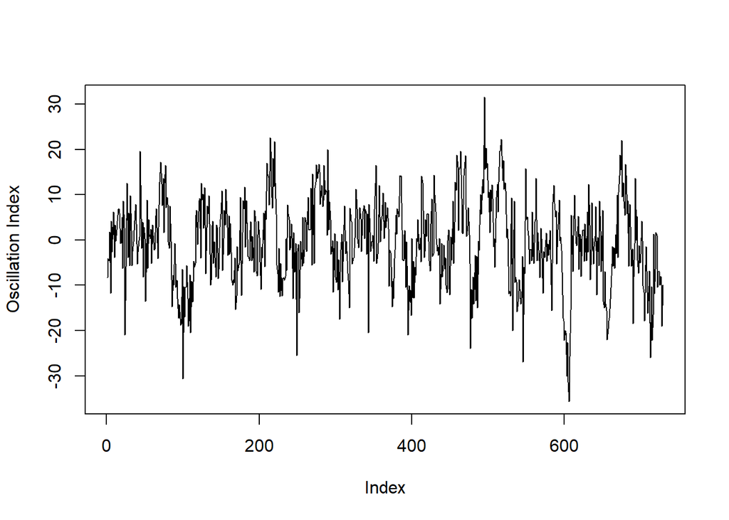

```r
plot(x$Index,type="l",ylab="Oscillation Index")
```

Now let’s look at the autocorrelation function corresponding to this dataset:

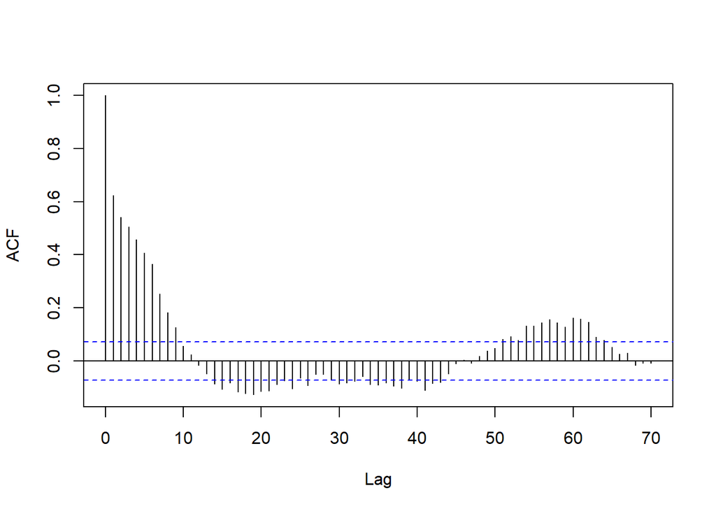

```r
acf(x$Index,lag.max=70,main="")
```

There is clear long-range oscillatory behaviour in the autocorrelation function, indicating that the process is not stationary.

We should consider an integrated (ARIMA) model, so let’s calculate and plot the first differences, as well as the associated autocorrelation function:

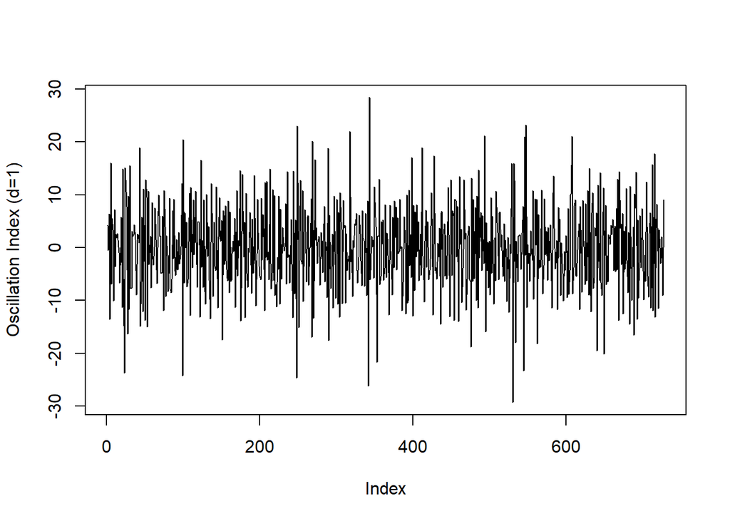

```r
plot(diff(x$Index),type="l",ylab="Oscillation Index (d=1)")
```

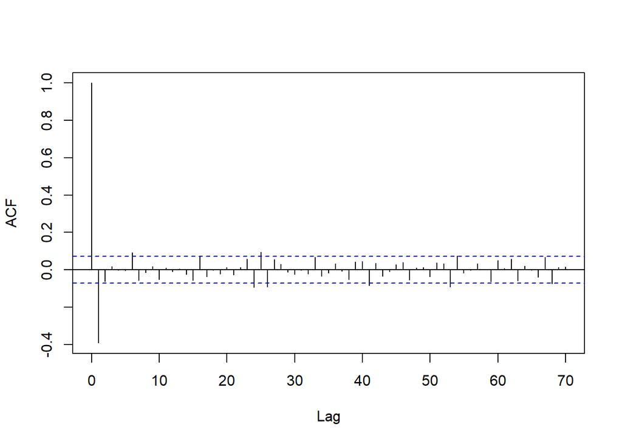

```r
acf(diff(x$Index),lag.max=70,main="")
```

That’s more promising - there is one large negative peak at lag=1, after which the autocorrelation function decays rapidly and stays small. This indicates that this process is covariance stationary. This also indicates that the Moving Average (MA) part of the model may be of order 1. So an ARIMA(0,1,1) model might be a possibility.

Now let’s look at the partial autocorrelation function:

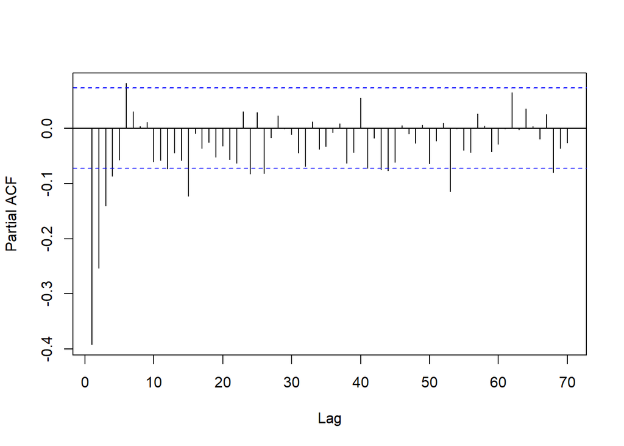

```r
pacf(diff(x$Index),lag.max=70,main="")
```

This also looks promising. There are four negative peaks before the PACF decays below the significance threshold. That indicates that the AutoRegressive (AR) part of the model may have order up to 4.

Now we’ll try to create an ARIMA(0,1,1) model:

```r
arima(x$Index,order=c(0,1,1))
```

```
##
## Call:
## arima(x = x$Index, order = c(0, 1, 1))
##
## Coefficients:
##           ma1
##       -0.5579
## s.e.   0.0308
##
## sigma^2 estimated as 52.94:  log likelihood = -2477.98,  aic = 4959.96
```

Note that the standard error of the coefficient indicates significance of the term.

Now try creating other ARIMA models, and compare.

There are a variety of time series datasets in the in-built R “datasets” package. Type `data()` to get a full list. For example, the datasets called `lh`, `ldeaths` and `presidents` are particularly appropriate for this type of analysis. Other datasets also contain time series data, including: `nhtemp`, `lynx`, `Nile`, `co2` and `WWWusage`. Explore such datasets - look at autocorrelation and partial autocorrelation functions, identify whether the datasets are suitable for time series analysis, and try fitting ARIMA models.